# Estudio variabilidad estructural proteica

## Conjuntos de proteinas

### Conjunto teorico

140 mutantes de 1phk (277 sitios) simuladas con el modelo mutacional LFENM con ANM *R0* = 12 y *Fmax* = 2 (solo para LFENM).

Con seleccion natural (ns = T): para determinar que sitios mutar, se alineo 1phk con cada una de las proteinas del conjunto, se obtuvieron los indices de los sitios alineados pero mutados y de los sitios con gaps y se simularon 10 mutantes por cada par de proteinas, obteniendose un total de 140 mutantes. Luego, para el analisis, se tomaron como alineados los sitios alineados de 1phk para cada par de proteinas.

Sin seleccion natural (ns = F): se mutaron al azar la cantidad de sitios correspondientes al % id del conjunto experimental y luego, para el analisis, se tomaron como alineados todos los sitios.

### Conjunto experimental

14 proteinas de la familia de kinase. Las proteinas tienen un promedio de identidad secuencial de 29%. El core del alineamiento de la familia es de 205 sitios.

### Analisis

Se realizaron 2 tipos de analisis:

*Core (C = T)*: se analizo solo el core conservado del alinemiento (sitios sin gaps en el alineamiento multiple).

*No Core (C = F)*: no se utilizo el core para el analisis.

La caracterizacion del conjunto experimental se muestra a continuacion:

```
##    pdbid nsites naligned identity       MSD
## 1   1csn    293      249 17.26908 11.032810
## 2   1a06    279      232 40.51724  6.597723
## 3  1cdka    343      255 34.50980  3.208082
## 4   1koa    350      260 31.15385  6.750351
## 5  1koba    353      259 31.27413  6.564354
## 6  1tkia    321      259 32.43243  6.647374
## 7   1jnk    346      246 27.23577 19.817823
## 8   1p38    351      246 29.67480 20.329043
## 9   3erk    350      251 31.07570 12.268922
## 10  1hcl    294      244 29.91803 21.240212
## 11 1blxa    305      249 31.72691 28.451726
## 12 1lr4a    327      253 25.69170 12.257752
## 13 1b6cb    326      253 22.13439 12.039235
## 14  1cki    292      249 17.26908 11.160774
```

## Comparaciones

### MSD

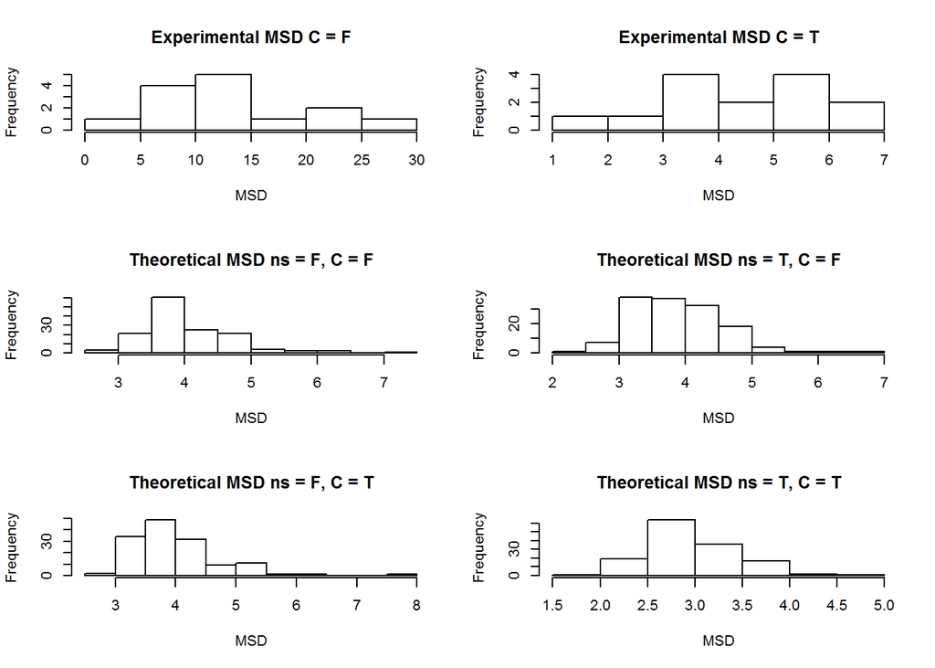

### MSDi

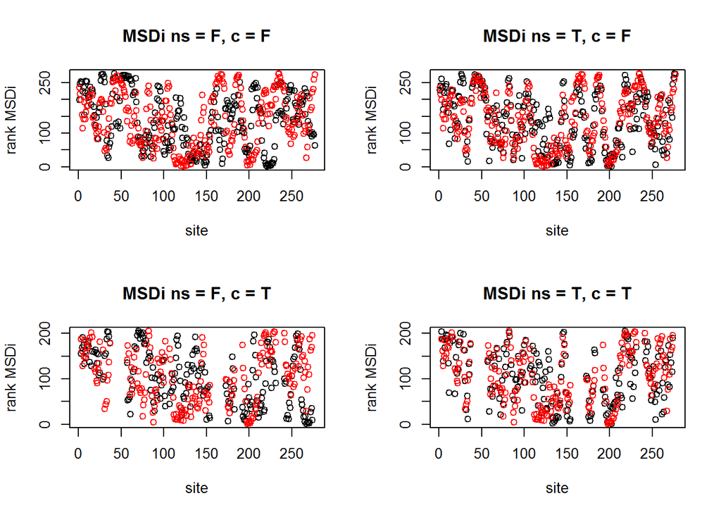

rojo: experimental negro: teorico

Los perfiles de MSDi fueron normalizados con la funcion rank().

### RHO y AUC

Las distribuciones de *auc* y *rho* para cada conjunto se muestran a continuacion (negro = teorico, rojo = experimental)

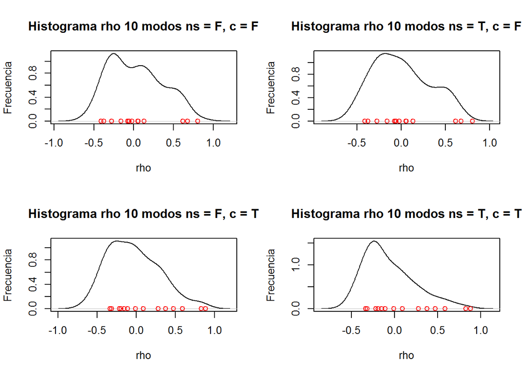

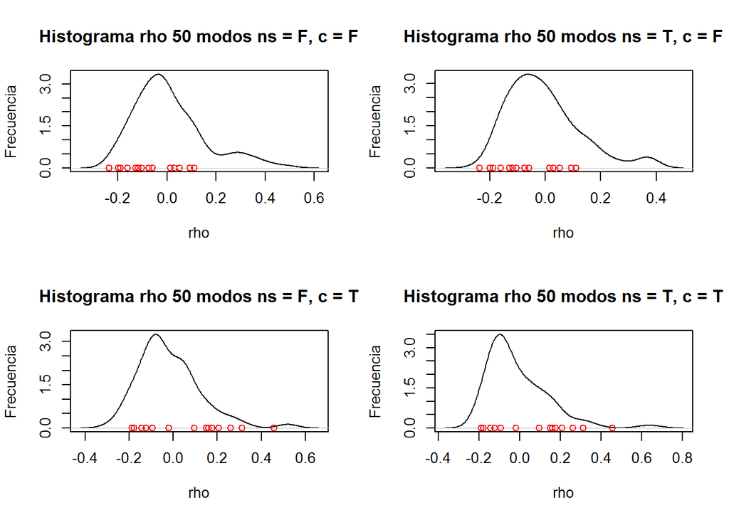

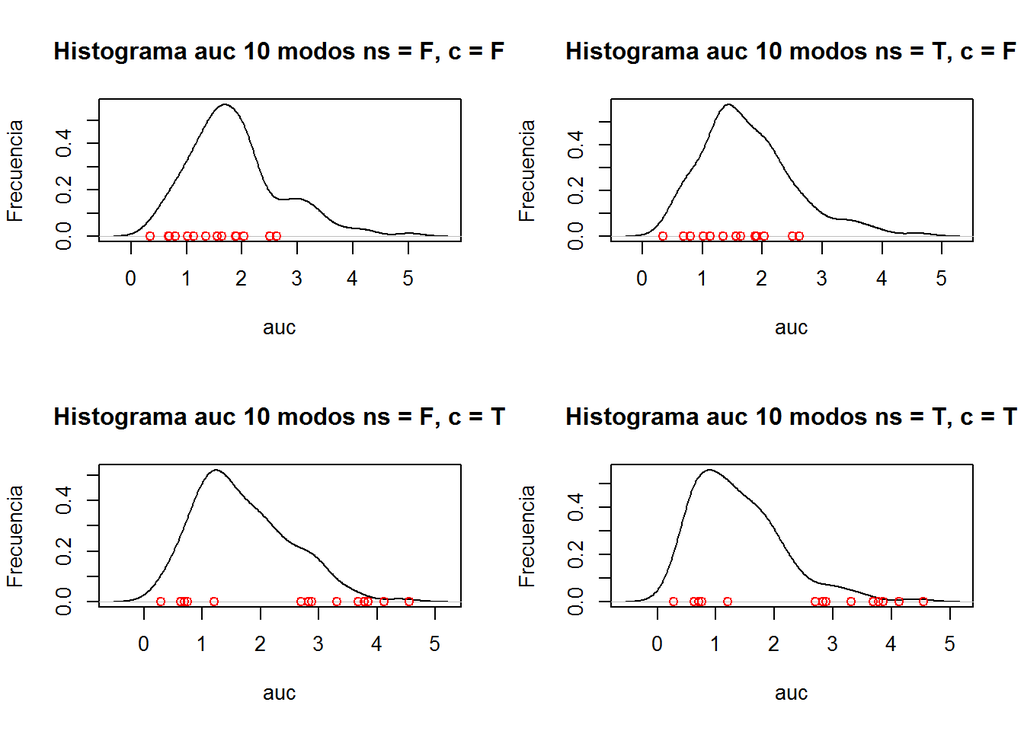

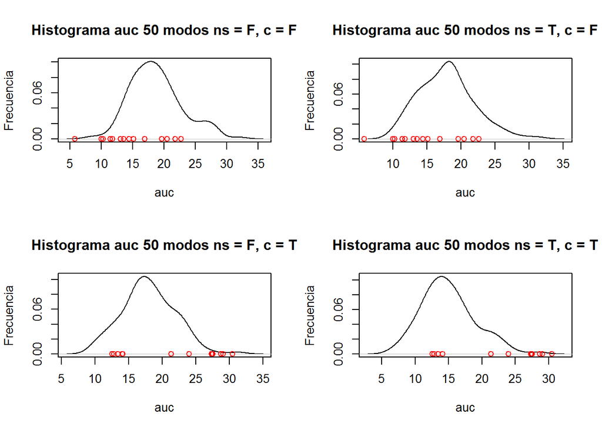

## Pn y Qn

Las distribuciones de *Pn* y *Qn* de los conjuntos son las siguientes:

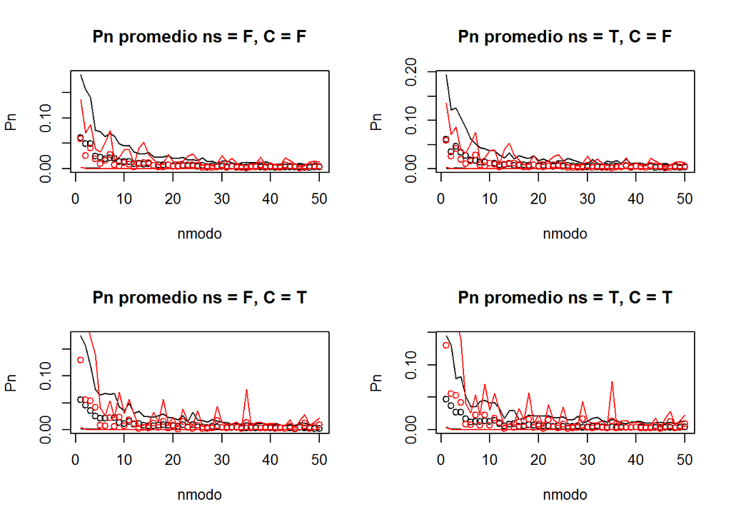

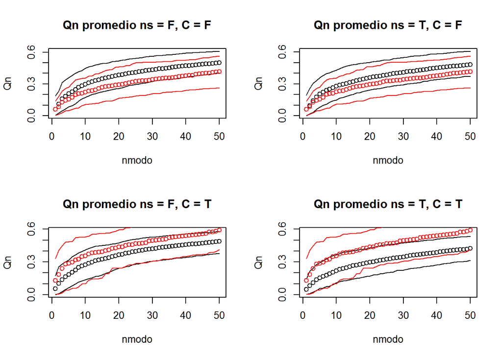

*Negro*: Puntos: promedio de promedios teorico. Lineas: promedio de cuantiles 0.05 y 0.95 de 10 grupos de 14 mutantes teoricas. *Rojo*: Experimental. Puntos: promedio. Lineas: cuantiles 0.05 y 0.95.

## R^2 y MSE

Las comparaciones entre perfines promedio Pn y MSDi teoricos fiteados y experimentales se muestran a continuacion. En cada grafico se muestra la correlacion (R^2) y el error (MSE).

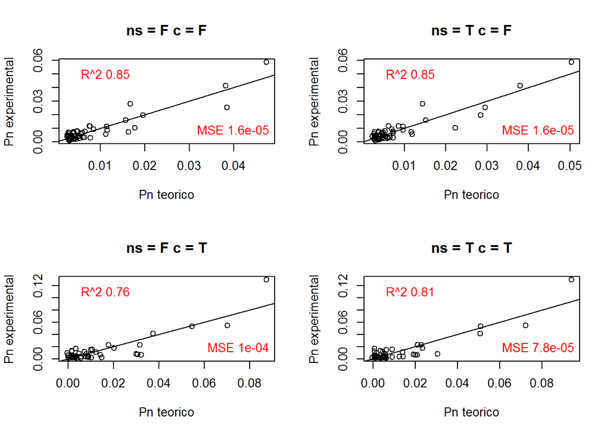

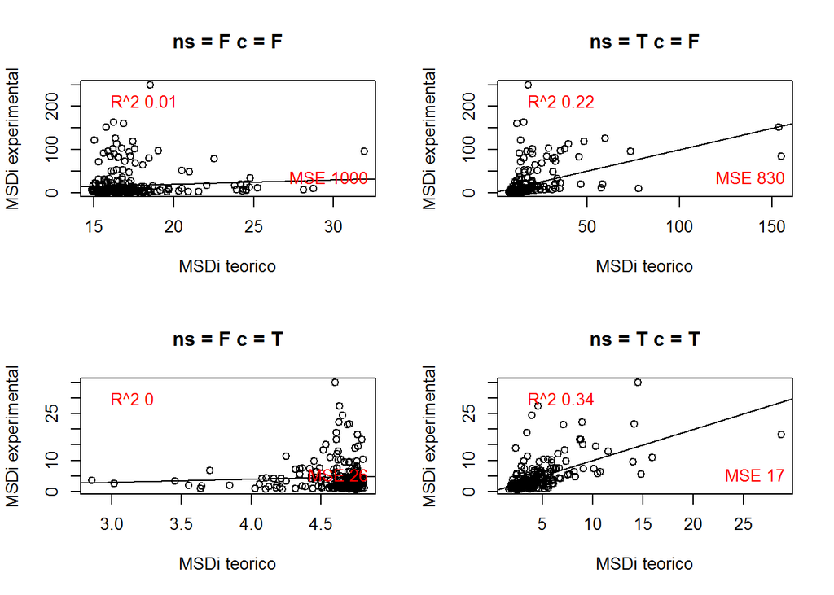